# Exploring the BRFSS data

Alex Kodess amkodess@gmail.com

http://www.cdc.gov/brfss/

## Setup

### Load packages

```r
library(tidyverse)
library(scales)
library(knitr)
```

### Load data

```r
load("brfss2013.RData")
```

## Part 1: Data

**Generalizability**: The data appear to be collected from a fairly large group of people, in different locations around the United States, via a variety of methods. Hence conclusions drawn from the data are generalizable.

**Causality**: However since the data are purely obsevational, all the conclusions are not causal. Only correlational relationships could be investigated.

## Part 2: Research questions

**Research quesion 1:** Investigate the classical question about whether there exists a relationship between one’s sleep times and one’s health status. To avoid a possible occurence of Simpson’s paradox, we divide observations by their gender.

**Research quesion 2:** Investigate a possible relationship between one’s self-reported health status and one’s education level. Split the exploratory analysis by gender.

**Research quesion 3:** How many people in New England cannot afford to see a doctor? We again split our analysis by gender.

## Part 3: Exploratory data analysis

**Research quesion 1. Sleep and health: variables `genhtlh`, `sleptim1`, `sex`**

The variables relevant to this question are `genhlth`,

```r
str(brfss2013$genhlth); summary(brfss2013$genhlth)
```

```
##  Factor w/ 5 levels "Excellent","Very good",..: 4 3 3 2 3 2 4 3 1 3 ...
```

```
## Excellent Very good      Good      Fair      Poor      NA's
##     85482    159076    150555     66726     27951      1985
```

`sleptim1`,

```r
str(brfss2013$sleptim1); summary(brfss2013$sleptim1)
```

```
##  int [1:491775] NA 6 9 8 6 8 7 6 8 8 ...
```

```
##    Min. 1st Qu.  Median    Mean 3rd Qu.    Max.    NA's
##   0.000   6.000   7.000   7.052   8.000 450.000    7387
```

and `sex`

```r
str(brfss2013$sex); summary(brfss2013$sex)
```

```
##  Factor w/ 2 levels "Male","Female": 2 2 2 2 1 2 2 2 1 2 ...
```

```
##   Male Female   NA's
## 201313 290455      7
```

First we realize that there are missing data as well as data that are obviously incorrect such as sleeping times exceeding 24 hours. We filter these out first.

```r
tb_1 <- brfss2013 %>%
        select(genhlth, sleptim1, sex) %>%
        filter(
                !is.na(genhlth),
                !is.na(sleptim1),
                !is.na(sex),
                sleptim1 <= 24
                )
```

We now find a summary of sleeping patterns among different groups of health status and different genders. The mean time is shown in minutes.

```r
tb_1 %>% group_by(genhlth, sex) %>%
        summarise(med_sleep = median(sleptim1),
                  mean_sleep = round(60*mean(sleptim1))) %>%
        ungroup() %>%
        arrange(desc(mean_sleep))
```

```
## # A tibble: 10 × 4
##      genhlth    sex med_sleep mean_sleep
##       <fctr> <fctr>     <dbl>      <dbl>
## 1  Excellent Female         7        434
## 2  Excellent   Male         7        428
## 3  Very good Female         7        428
## 4  Very good   Male         7        423
## 5       Good Female         7        423
## 6       Good   Male         7        422
## 7       Fair   Male         7        416
## 8       Fair Female         7        412
## 9       Poor   Male         7        406
## 10      Poor Female         6        403
```

These data are now visualized using side-by-side boxplots. The data are faceted by gender.

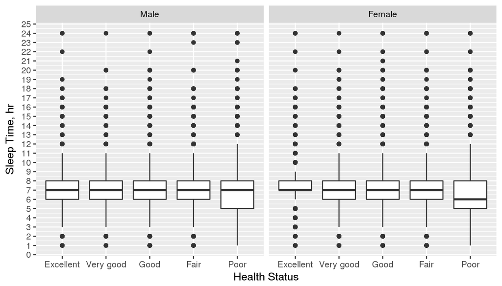

```r
ggplot(
        data = tb_1,
        mapping = aes(x = genhlth, y = sleptim1)
        ) +
        geom_boxplot() +
        scale_y_continuous(breaks = pretty_breaks(n = 24)) +
        labs(x = "Health Status", y = "Sleep Time, hr") +
        facet_wrap(~ sex)
```

**Research quesion 2. Education and health: variables `genhlth`, `sex`, `educa`**

The variables relevant to this question are `genhlth`, `sex`, and `educa`

```r
str(brfss2013$educa); summary(brfss2013$educa)
```

```
##  Factor w/ 6 levels "Never attended school or only kindergarten",..: 6 5 6 4 6 6 4 5 6 4 ...
```

```
##                   Never attended school or only kindergarten
##                                                          677
##                              Grades 1 through 8 (Elementary)
##                                                        13395
##                        Grades 9 though 11 (Some high school)
##                                                        28141
##                       Grade 12 or GED (High school graduate)
##                                                       142971
## College 1 year to 3 years (Some college or technical school)
##                                                       134197
##                   College 4 years or more (College graduate)
##                                                       170120
##                                                         NA's
##                                                         2274
```

We first obtan all the observations were all three variables are available.

```r
tb_2 <- brfss2013 %>%
        select(genhlth, educa, sex) %>%
        filter(
                !is.na(genhlth),
                !is.na(educa),
                !is.na(sex)
                )
```

We shorten the names of the factor levels of `educa` for aesthetic reasons.

```r
levels(tb_2$educa) <- c(
                                "Only kindergarten",
                                "Elementary",
                                "Some High School",
                                "High School graduate",
                                "College dropped",
                                "College graduate"
)
```

This gives us a contingency table for `educa` and `genhlth` (regardless of `sex`)

```r
cont_tab <- table(tb_2$educa, tb_2$genhlth)
round(100*prop.table(cont_tab), 4)
```

```
##
##                        Excellent Very good    Good    Fair    Poor
##   Only kindergarten       0.0115    0.0168  0.0412  0.0408  0.0242
##   Elementary              0.1846    0.2978  0.8147  0.8990  0.5160
##   Some High School        0.4678    0.9652  1.9070  1.5495  0.8337
##   High School graduate    3.6000    8.1666 10.2988  5.0484  2.0869
##   College dropped         4.3783    9.2011  8.7841  3.6184  1.4482
##   College graduate        8.8014   13.8610  8.8859  2.4606  0.7903
```

These data are now visualized using bar plots. The data are faceted by gender.

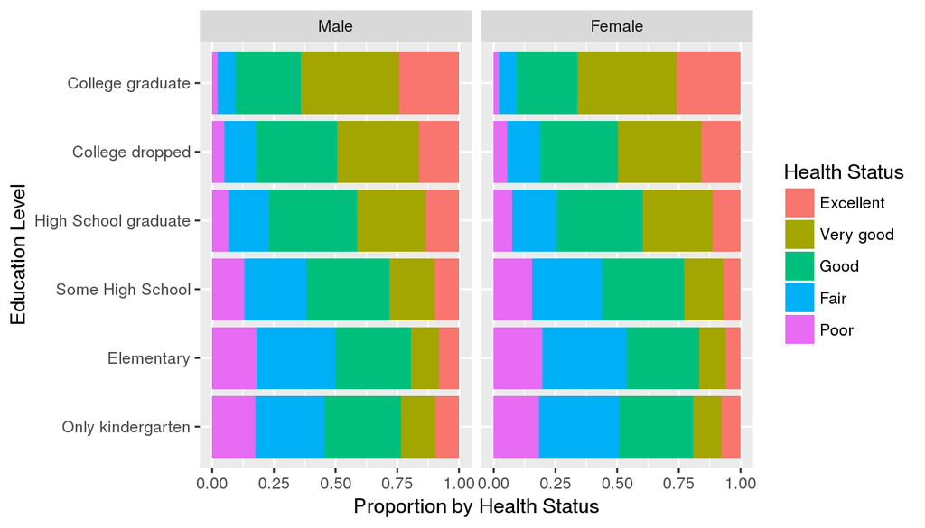

```r
ggplot(
        data = tb_2,
        aes(x = educa, fill = genhlth)) +
        geom_bar(position = "fill") +
        labs(x = "Education Level",
             y = "Proportion by Health Status"
        )+
        scale_fill_discrete('Health Status') +
        coord_flip() +
        facet_wrap(~ sex)
```

**Research quesion 3: How many people cannot afford a doctor in New England? variables `X_state`, `sex`, `medcost`**

We first of all realize that the variable `_state` is not present in the dataset, and we should use `X_state`.

```r
str(brfss2013$X_state); summary(brfss2013$X_state)
```

```
##  Factor w/ 55 levels "0","Alabama",..: 2 2 2 2 2 2 2 2 2 2 ...
```

```
##                    0              Alabama               Alaska
##                    1                 6505                 4578
##              Arizona             Arkansas           California
##                 4253                 5268                11518
##             Colorado          Connecticut             Delaware
##                13649                 7710                 5206
## District of Columbia              Florida              Georgia
##                 4931                33668                 8658
##               Hawaii                Idaho             Illinois
##                 7858                 5630                 5608
##              Indiana                 Iowa               Kansas
##                10338                 8157                23282
##             Kentucky            Louisiana                Maine
##                10877                 5215                 8273
##             Maryland        Massachusetts             Michigan
##                13011                15071                12761
##            Minnesota          Mississippi             Missouri
##                14340                 7453                 7118
##              Montana             Nebraska               Nevada
##                 9693                17139                 5101
##        New Hampshire           New Jersey           New Mexico
##                 6076                13776                 9316
##             New York       North Carolina         North Dakota
##                 8979                 8860                 7806
##                 Ohio             Oklahoma               Oregon
##                11971                 8244                 5949
##         Pennsylvania         Rhode Island       South Carolina
##                11429                 6531                10717
##         South Dakota            Tennessee                Texas
##                 6895                 5815                10917
##                 Utah              Vermont             Virginia
##                12769                 6392                 8464
##           Washington        West Virginia            Wisconsin
##                11162                 5899                 6589
##              Wyoming                 Guam          Puerto Rico
##                 6454                 1897                 5997
##                   80
##                    1
```

The other two variables involved in this question are `sex` and `medcost`:

```r
str(brfss2013$medcost); summary(brfss2013$medcost)
```

```
##  Factor w/ 2 levels "Yes","No": 2 2 2 2 2 2 2 2 2 2 ...
```

```
##    Yes     No   NA's
##  60107 430447   1221
```

We define `New_England` as the following six states in the Northest US.

```r
New_England <- c(
                        "Connecticut",
                        "Maine",
                        "Massachusetts",
                        "New Hampshire",
                        "Rhode Island",
                        "Vermont"
)
```

We select the needed variables, group them by gender and state, and compute in each group the proportion of people who answered positively to the question *Was there a time in the past 12 months when you needed to see a doctor but could not because of cost?*

```r
tb_3 <- brfss2013 %>%
        select(X_state, medcost, sex) %>%
        filter(
                X_state %in% New_England,
                !is.na(medcost),
                !is.na(sex)
        ) %>%
        group_by(sex, X_state) %>%
        summarise(
                perc = length(medcost[medcost == "Yes"]) / n()
        )

print(tb_3)
```

```
## Source: local data frame [12 x 3]
## Groups: sex [?]
##
##       sex       X_state       perc
##    <fctr>        <fctr>      <dbl>
## 1    Male   Connecticut 0.09547739
## 2    Male         Maine 0.08095378
## 3    Male Massachusetts 0.08229010
## 4    Male New Hampshire 0.07695343
## 5    Male  Rhode Island 0.10940575
## 6    Male       Vermont 0.07259866
## 7  Female   Connecticut 0.11244178
## 8  Female         Maine 0.08647313
## 9  Female Massachusetts 0.07927570
## 10 Female New Hampshire 0.11422902
## 11 Female  Rhode Island 0.12005044
## 12 Female       Vermont 0.07933929
```

These data are now visualized using bar plots. The data are faceted by gender.

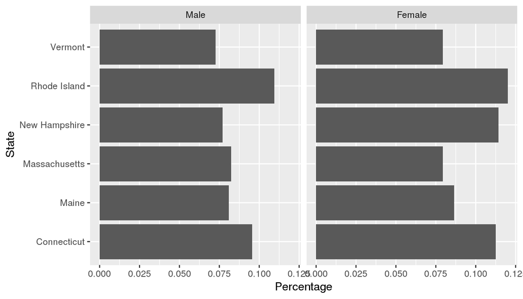

```r
tb_3$X_state = factor(tb_3$X_state)
ggplot(
        data = tb_3,
        aes(x = X_state, y = perc)) +
        geom_col() +
        labs(x = "State", y = "Percentage") +
        coord_flip() +
        facet_wrap(~ sex)
```